# Biostat 203B Homework 5

Due Mar 22 @ 11:59PM

Author

Yuxin Zhang 406328706

## Predicting ICU duration

Using the ICU cohort `mimiciv_icu_cohort.rds` you built in Homework 4, develop at least three machine learning approaches (logistic regression with enet regularization, random forest, boosting, SVM, MLP, etc) plus a model stacking approach for predicting whether a patient’s ICU stay will be longer than 2 days. You should use the `los_long` variable as the outcome. You algorithms can use patient demographic information (gender, age at ICU `intime`, marital status, race), ICU admission information (first care unit), the last lab measurements before the ICU stay, and first vital measurements during ICU stay as features. You are welcome to use any feature engineering techniques you think are appropriate; but make sure to not use features that are not available at an ICU stay’s `intime`. For instance, `last_careunit` cannot be used in your algorithms.

1. Data preprocessing and feature engineering.
2. Partition data into 50% training set and 50% test set. Stratify partitioning according to `los_long`. For grading purpose, sort the data by `subject_id`, `hadm_id`, and `stay_id` and use the seed `203` for the initial data split. Below is the sample code.

```r
library(tidyverse)
library(tidymodels)
library(gtsummary)
library(GGally)
library(gtsummary)
library(ranger)
library(ggplot2)
library(tune)
library(finetune)
```

```r
set.seed(203)
mimiciv_icu_cohort <- readRDS("../hw4/mimiciv_shiny/mimic_icu_cohort.rds")
# sort
mimiciv_icu_cohort <- mimiciv_icu_cohort |>
  arrange(subject_id, hadm_id, stay_id) |>
  select(insurance, admission_type, admission_location,
         first_careunit, age_intime, gender, race, marital_status, 29:42 ) |>
  mutate(los_long = as.factor(los_long)) |>
  print(width = Inf)
```

```
# A tibble: 73,181 × 22
   insurance admission_type              admission_location
   <chr>     <fct>                       <fct>
 1 Medicaid  EW EMER.                    EMERGENCY ROOM
 2 Medicare  EW EMER.                    EMERGENCY ROOM
 3 Other     EW EMER.                    EMERGENCY ROOM
 4 Other     Other                       PHYSICIAN REFERRAL
 5 Other     EW EMER.                    Other
 6 Medicare  OBSERVATION ADMIT           EMERGENCY ROOM
 7 Medicare  SURGICAL SAME DAY ADMISSION PHYSICIAN REFERRAL
 8 Other     EW EMER.                    EMERGENCY ROOM
 9 Other     EW EMER.                    Other
10 Other     EW EMER.                    EMERGENCY ROOM
   first_careunit                                   age_intime gender race
   <fct>                                                 <int> <chr>  <fct>
```

[output cut: 59 more lines]

```r
attach(mimiciv_icu_cohort)
```

```r
data_split <- initial_split(
  mimiciv_icu_cohort,
  # stratify by los_long
  strata = "los_long",
  prop = 0.5
  )
```

```r
mimiciv_icu_cohort |> tbl_summary(by = los_long)
```

| **Characteristic** | **FALSE**, N = 38,050<sup>1</sup> | **TRUE**, N = 35,131<sup>1</sup> |
| --- | --- | --- |
| insurance |  |  |
| Medicaid | 3,060 (8.0%) | 2,468 (7.0%) |
| Medicare | 16,489 (43%) | 16,602 (47%) |
| Other | 18,501 (49%) | 16,061 (46%) |
| admission_type |  |  |
| EW EMER. | 20,735 (54%) | 17,937 (51%) |
| OBSERVATION ADMIT | 4,329 (11%) | 4,645 (13%) |
| SURGICAL SAME DAY ADMISSION | 4,340 (11%) | 3,033 (8.6%) |
| URGENT | 5,494 (14%) | 6,959 (20%) |
| Other | 3,152 (8.3%) | 2,557 (7.3%) |
| admission_location |  |  |
| EMERGENCY ROOM | 19,602 (52%) | 16,279 (46%) |
| PHYSICIAN REFERRAL | 8,986 (24%) | 7,412 (21%) |
| TRANSFER FROM HOSPITAL | 6,839 (18%) | 8,959 (26%) |
| WALK-IN/SELF REFERRAL | 876 (2.3%) | 791 (2.3%) |
| Other | 1,747 (4.6%) | 1,690 (4.8%) |
| first_careunit |  |  |
| Cardiac Vascular Intensive Care Unit (CVICU) | 5,827 (15%) | 5,755 (16%) |
| Medical Intensive Care Unit (MICU) | 8,782 (23%) | 7,116 (20%) |
| Medical/Surgical Intensive Care Unit (MICU/SICU) | 7,147 (19%) | 5,586 (16%) |
| Surgical Intensive Care Unit (SICU) | 5,654 (15%) | 5,507 (16%) |
| Other | 10,640 (28%) | 11,167 (32%) |
| age_intime | 65 (53, 77) | 67 (56, 78) |
| gender |  |  |
| F | 17,014 (45%) | 15,349 (44%) |
| M | 21,036 (55%) | 19,782 (56%) |
| race |  |  |
| ASIAN | 1,148 (3.0%) | 1,007 (2.9%) |
| BLACK | 4,311 (11%) | 3,649 (10%) |
| HISPANIC | 1,492 (3.9%) | 1,249 (3.6%) |
| Other | 5,160 (14%) | 5,596 (16%) |
| WHITE | 25,939 (68%) | 23,630 (67%) |
| marital_status |  |  |
| DIVORCED | 2,843 (8.0%) | 2,561 (7.9%) |
| MARRIED | 16,984 (48%) | 15,784 (49%) |
| SINGLE | 11,175 (31%) | 9,683 (30%) |
| WIDOWED | 4,699 (13%) | 4,339 (13%) |
| Unknown | 2,349 | 2,764 |
| creatinine | 1.00 (0.80, 1.40) | 1.00 (0.80, 1.60) |
| Unknown | 2,599 | 3,171 |
| sodium | 139.0 (136.0, 141.0) | 138.0 (135.0, 141.0) |
| Unknown | 4,174 | 4,698 |
| glucose | 118 (98, 153) | 122 (100, 159) |
| Unknown | 4,282 | 4,817 |
| potassium | 4.20 (3.80, 4.60) | 4.20 (3.80, 4.70) |
| Unknown | 4,189 | 4,712 |
| wbc | 9.0 (6.6, 12.6) | 9.7 (7.0, 13.8) |
| Unknown | 2,272 | 2,822 |
| bicarbonate | 25.0 (22.0, 27.0) | 24.0 (21.0, 27.0) |
| Unknown | 4,270 | 4,780 |
| chloride | 102 (98, 105) | 102 (98, 105) |
| Unknown | 4,175 | 4,708 |
| hematocrit | 36 (30, 40) | 35 (29, 40) |
| Unknown | 2,236 | 2,781 |
| Heart_Rate | 85 (74, 99) | 88 (76, 103) |
| Unknown | 17 | 1 |
| Temperature_Fahrenheit | 98.10 (97.60, 98.60) | 98.20 (97.60, 98.80) |
| Unknown | 1,189 | 173 |
| Non_Invasive_Blood_Pressure_systolic | 122 (107, 139) | 120 (104, 138) |
| Unknown | 732 | 247 |
| Non_Invasive_Blood_Pressure_diastolic | 68 (58, 80) | 66 (55, 79) |
| Unknown | 733 | 250 |
| Respiratory_Rate | 18.0 (15.0, 22.0) | 19.0 (15.0, 23.0) |
| Unknown | 87 | 11 |

<sup>1</sup> n (%); Median (IQR)

Train and tune the models using the training set.

```r
mimic_other <- training(data_split)
dim(mimic_other)
```

```
[1] 36590    22
```

```r
mimic_test <- testing(data_split)
dim(mimic_test)
```

```
[1] 36591    22
```

```r
set.seed(203)

folds <- vfold_cv(mimic_other, v = 5)
folds
```

```
#  5-fold cross-validation
# A tibble: 5 × 2
  splits               id
  <list>               <chr>
1 <split [29272/7318]> Fold1
2 <split [29272/7318]> Fold2
3 <split [29272/7318]> Fold3
4 <split [29272/7318]> Fold4
5 <split [29272/7318]> Fold5
```

### Random forest

#### Recipe

```r
rf_recipe <-
  recipe(
    los_long ~ .,
    data = mimic_other
  ) |>
  step_impute_mean(9:21) |>
  step_impute_mode(marital_status) |>
  step_zv(all_numeric_predictors()) |>
  print()
```

```
── Recipe ──────────────────────────────────────────────────────────────────────
```

```
── Inputs
```

```
Number of variables by role
```

```
outcome:    1
predictor: 21
```

```
── Operations
```

```
• Mean imputation for: 9:21
```

```
• Mode imputation for: marital_status
```

```
• Zero variance filter on: all_numeric_predictors()
```

#### Model

```r
rf_mod <-
  rand_forest(
    mode = "classification",
    mtry = tune(),
    trees = tune()
  ) |>
  set_engine("ranger", importance = "impurity")
rf_mod
```

```
Random Forest Model Specification (classification)

Main Arguments:
  mtry = tune()
  trees = tune()

Engine-Specific Arguments:
  importance = impurity

Computational engine: ranger
```

#### Workflow

```r
rf_wf <- workflow() |>
  add_recipe(rf_recipe) |>
  add_model(rf_mod)
rf_wf
```

```
══ Workflow ════════════════════════════════════════════════════════════════════
Preprocessor: Recipe
Model: rand_forest()

── Preprocessor ────────────────────────────────────────────────────────────────
3 Recipe Steps

• step_impute_mean()
• step_impute_mode()
• step_zv()

── Model ───────────────────────────────────────────────────────────────────────
Random Forest Model Specification (classification)

Main Arguments:
  mtry = tune()
  trees = tune()

Engine-Specific Arguments:
  importance = impurity

Computational engine: ranger
```

#### Tuning

```r
param_grid <- grid_regular(
  trees(range = c(500L, 1000L)),
  mtry(range = c(1L, 5L)),
  levels = c(5, 5)
  )
param_grid
```

```
# A tibble: 25 × 2
   trees  mtry
   <int> <int>
 1   500     1
 2   625     1
 3   750     1
 4   875     1
 5  1000     1
 6   500     2
 7   625     2
 8   750     2
 9   875     2
10  1000     2
# ℹ 15 more rows
```

#### Cross-validation

```r
rf_fit <- rf_wf |>
  tune_grid(
    resamples = folds,
    grid = param_grid,
    metrics = metric_set(roc_auc, accuracy),
    control = control_stack_grid()
    )
saveRDS(rf_fit, "rf_fit.rds")
```

```r
rf_fit <- readRDS("rf_fit.rds")
rf_fit
```

```
# Tuning results
# 5-fold cross-validation
# A tibble: 5 × 5
  splits               id    .metrics          .notes           .predictions
  <list>               <chr> <list>            <list>           <list>
1 <split [29272/7318]> Fold1 <tibble [50 × 6]> <tibble [0 × 3]> <tibble>
2 <split [29272/7318]> Fold2 <tibble [50 × 6]> <tibble [0 × 3]> <tibble>
3 <split [29272/7318]> Fold3 <tibble [50 × 6]> <tibble [0 × 3]> <tibble>
4 <split [29272/7318]> Fold4 <tibble [50 × 6]> <tibble [0 × 3]> <tibble>
5 <split [29272/7318]> Fold5 <tibble [50 × 6]> <tibble [0 × 3]> <tibble>
```

```
# A tibble: 50 × 8
    mtry trees .metric  .estimator  mean     n std_err .config
   <int> <int> <chr>    <chr>      <dbl> <int>   <dbl> <chr>
 1     1   500 accuracy binary     0.600     5 0.00269 Preprocessor1_Model01
 2     1   500 roc_auc  binary     0.644     5 0.00269 Preprocessor1_Model01
 3     1   625 accuracy binary     0.598     5 0.00382 Preprocessor1_Model02
 4     1   625 roc_auc  binary     0.645     5 0.00302 Preprocessor1_Model02
 5     1   750 accuracy binary     0.600     5 0.00305 Preprocessor1_Model03
 6     1   750 roc_auc  binary     0.644     5 0.00268 Preprocessor1_Model03
 7     1   875 accuracy binary     0.600     5 0.00356 Preprocessor1_Model04
 8     1   875 roc_auc  binary     0.644     5 0.00286 Preprocessor1_Model04
 9     1  1000 accuracy binary     0.601     5 0.00331 Preprocessor1_Model05
10     1  1000 roc_auc  binary     0.645     5 0.00276 Preprocessor1_Model05
# ℹ 40 more rows
```

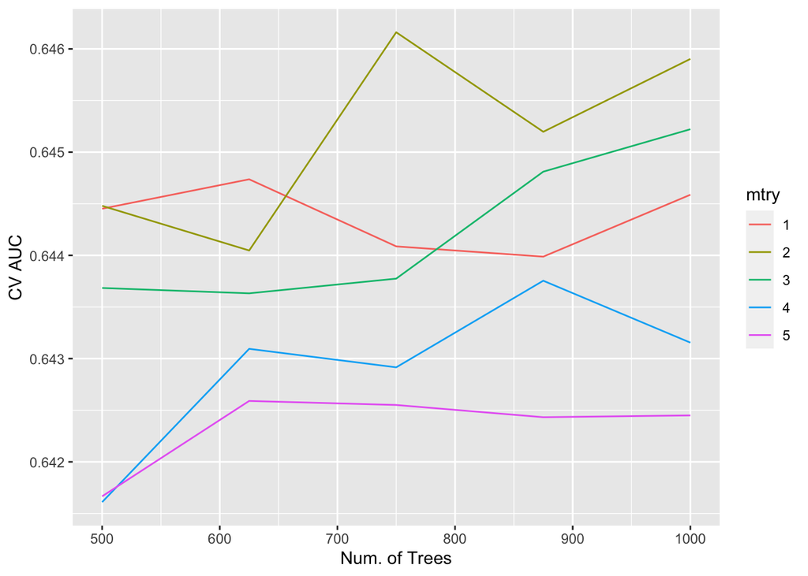

```r
rf_fit %>%
  collect_metrics() %>%
  print(width = Inf) %>%
  filter(.metric == "roc_auc") %>%
  mutate(mtry = as.factor(mtry)) %>%
  ggplot(mapping = aes(x = trees, y = mean, color = mtry)) +
  # geom_point() +
  geom_line() +
  labs(x = "Num. of Trees", y = "CV AUC")
```

```r
rf_fit |>
  show_best("roc_auc")
```

```
# A tibble: 5 × 8
   mtry trees .metric .estimator  mean     n std_err .config
  <int> <int> <chr>   <chr>      <dbl> <int>   <dbl> <chr>
1     2   750 roc_auc binary     0.646     5 0.00300 Preprocessor1_Model08
2     2  1000 roc_auc binary     0.646     5 0.00269 Preprocessor1_Model10
3     3  1000 roc_auc binary     0.645     5 0.00367 Preprocessor1_Model15
4     2   875 roc_auc binary     0.645     5 0.00349 Preprocessor1_Model09
5     3   875 roc_auc binary     0.645     5 0.00321 Preprocessor1_Model14
```

```r
best_rf <- rf_fit |>
  select_best("roc_auc")
best_rf
```

```
# A tibble: 1 × 3
   mtry trees .config
  <int> <int> <chr>
1     2   750 Preprocessor1_Model08
```

#### Finalize the workflow

```r
# Final workflow
final_wf_rf <- rf_wf |>
  finalize_workflow(best_rf)
final_wf_rf
```

```
══ Workflow ════════════════════════════════════════════════════════════════════
Preprocessor: Recipe
Model: rand_forest()

── Preprocessor ────────────────────────────────────────────────────────────────
3 Recipe Steps

• step_impute_mean()
• step_impute_mode()
• step_zv()

── Model ───────────────────────────────────────────────────────────────────────
Random Forest Model Specification (classification)

Main Arguments:
  mtry = 2
  trees = 750

Engine-Specific Arguments:
  importance = impurity

Computational engine: ranger
```

```r
final_fit_rf <-
  final_wf_rf |>
  last_fit(data_split)
final_fit_rf
```

```
# Resampling results
# Manual resampling
# A tibble: 1 × 6
  splits                id             .metrics .notes   .predictions .workflow
  <list>                <chr>          <list>   <list>   <list>       <list>
1 <split [36590/36591]> train/test sp… <tibble> <tibble> <tibble>     <workflow>
```

```r
final_fit_rf |>
  collect_metrics()
```

```
# A tibble: 2 × 4
  .metric  .estimator .estimate .config
  <chr>    <chr>          <dbl> <chr>
1 accuracy binary         0.605 Preprocessor1_Model1
2 roc_auc  binary         0.645 Preprocessor1_Model1
```

#### Visualize the final model

```r
library(rpart.plot)
final_tree <- extract_workflow(final_fit_rf)
final_tree
```

```
══ Workflow [trained] ══════════════════════════════════════════════════════════
Preprocessor: Recipe
Model: rand_forest()

── Preprocessor ────────────────────────────────────────────────────────────────
3 Recipe Steps

• step_impute_mean()
• step_impute_mode()
• step_zv()

── Model ───────────────────────────────────────────────────────────────────────
Ranger result

Call:
 ranger::ranger(x = maybe_data_frame(x), y = y, mtry = min_cols(~2L,      x), num.trees = ~750L, importance = ~"impurity", num.threads = 1,      verbose = FALSE, seed = sample.int(10^5, 1), probability = TRUE)

Type:                             Probability estimation
Number of trees:                  750
Sample size:                      36590
Number of independent variables:  21
Mtry:                             2
Target node size:                 10
Variable importance mode:         impurity
Splitrule:                        gini
OOB prediction error (Brier s.):  0.2342045
```

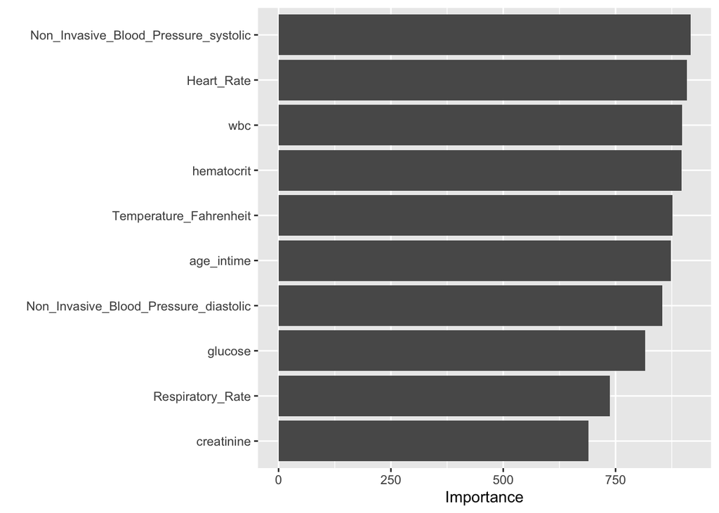

```r
library(vip)
final_tree %>%
  extract_fit_parsnip() %>%
  vip()
```

The model has an AUC of 0.65 and an accuracy of 0.60 for the test data. `Non_Invasive_Blood_Pressure_systotic` seems to be the most important feature in the model.